# MATH_6395_Homework_3_PRN_simulation

## MATH 6395: Homework #3 - PRN Simulation by Barry Daemi $$\newcommand{\C}{\mathbb{C}} \newcommand{\R}{\mathbb{R}} \newcommand{\Z}{\mathbb{Z}} \newcommand{\Q}{\mathbb{Q}} \newcommand{\P}{\mathbb{P}} \newcommand{\F}{\mathbb{F}} \newcommand{\N}{\mathbb{N}} \newcommand{\E}{\mathbb{E}}$$

**Question 1**  
Use acceptance-Rejection algorithm to generate 10000 samples for $\text{Beta}(\alpha,\beta)$ distribution for $\alpha = 2$, $\beta = 5$ and plot the approximate pdf by using the sample (# of samples per 0.01 interval) against the exact pdf.  
*solution:*

First have to import the python packages that will be used.

```python
import numpy as np
import pandas as pd
from scipy.stats import norm
import matplotlib.pyplot as plt
from scipy.special import gamma
import seaborn as sns
sns.set()
np.random.seed(523)
```

For a quick experiment, let's generate a pseudo-random number (PRN) sampling of a uniform random variable over the interval $(0,1)$.

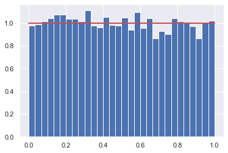

```python
n=10000;
X=np.random.uniform(0,1,n);
count, bins, ignored = plt.hist(X, 30, density=True);
plt.plot(bins, np.ones_like(bins), linewidth=2, color='r');
plt.show();
```

Let define the beta pdf as a function `pdf(x)`, and the beta generation (or sampling) process as another function `beta_gen(n)`.

```python
def pdf(x):
    alpha=2;
    beta=5;
    beta_fun=gamma(alpha)*gamma(beta)/gamma(alpha+beta);
    prob=x**(alpha-1)*(1-x)**(beta-1);

    return 1/beta_fun*prob;

def beta_gen(n):
    i = 0;
    c=pdf(mode);
    output = np.zeros(n);
    while i < n:
        U = np.random.uniform(size = 1);
        V = np.random.uniform(size = 1);
        if U < 1/c*pdf(V):
            output[i] = V;
            i = i + 1;
    return output;
```

Now we can execute the previously defined functions in a example scrip to generate the desired beta distribution, $\text{Beta}(\alpha=2,\beta=5)$

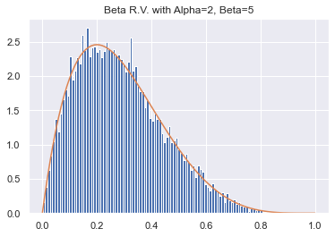

```python
alpha=2;
beta=5;
n=10000;

#Mode of Beta distribution
mode=(alpha-1)/(2.7+beta-2);

x=np.arange(0,1.01,0.01);
y=pdf(x);

Y=beta_gen(n);

fig,ax = plt.subplots();
temp = ax.hist(Y,100,density=True);
ax.plot(x,y);
plt.title("Beta R.V. with Alpha=2, Beta=5");
plt.show();
```

**Question 2**  
Use Box-Muller Method to generate 10000 sample of a normal distribution $X$ and plot it approximate pdf as above against the exact pdf.  
*solution:*

As the Box-Muller method is quite simple to implement, we will just compose a simple python script for it.

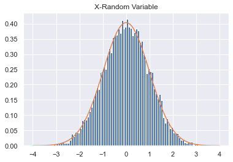

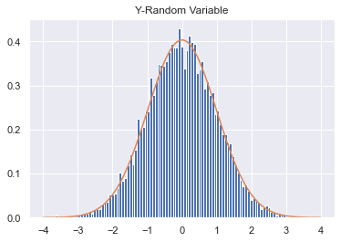

```python
n=10000;
U1=np.random.uniform(0,1,n);
U2=np.random.uniform(0,1,n);
X=np.sqrt(-2*np.log(U1))*np.cos(2*np.pi*U2);
Y=np.sqrt(-2*np.log(U1))*np.sin(2*np.pi*U2);

# Plots random variable X
count,bins,ignored=plt.hist(X, 100, density=True);


# Plot between -4 and 4 with
x_axis=np.arange(-4,4,0.01);

# Calculates the mean and variance for random variable X
mean=np.mean(X);
sd=np.std(X);

# Plots the true Normal Distribution curve
plt.plot(x_axis,norm.pdf(x_axis,mean,sd));
plt.title("X-Random Variable")
plt.show();

# Plots random variable Y
count,bins,ignored=plt.hist(Y, 100, density=True);

# Calculates the mean and variance for random variable Y
mean=np.mean(X);
sd=np.std(X);

# Plots the true Normal Distribution curve
plt.plot(x_axis,norm.pdf(x_axis,mean,sd));
plt.title("Y-Random Variable")
plt.show();
```